# Dataset Overview

##### **This data is provided according to the Ford GoBike Data License Agreement.**

We have collected data from ford go bike website and we are trying to analyse the data.

In this analysis we have used only data for year 2018 and we have tried to draw the following conclusions from it

```python
import pandas as pd
import numpy as np
import matplotlib.pyplot as plt
import seaborn as sns
%matplotlib inline
```

```python
%time


df1 = pd.read_csv('201801-fordgobike-tripdata.csv')
df2 = pd.read_csv('201802-fordgobike-tripdata.csv')
df3 = pd.read_csv('201803-fordgobike-tripdata.csv')
df4 = pd.read_csv('201804-fordgobike-tripdata.csv')
df5 = pd.read_csv('201805-fordgobike-tripdata.csv')
df6 = pd.read_csv('201806-fordgobike-tripdata.csv')
df7 = pd.read_csv('201807-fordgobike-tripdata.csv')
df8 = pd.read_csv('201808-fordgobike-tripdata.csv')
df9 = pd.read_csv('201809-fordgobike-tripdata.csv')
df10 = pd.read_csv('201810-fordgobike-tripdata.csv')
df11 = pd.read_csv('201811-fordgobike-tripdata.csv')
```

```
Wall time: 0 ns
```

```python
df = pd.concat([df1, df2, df3, df4, df5, df6, df7, df8, df9, df10, df11])
```

```python
df.to_csv('fordgobike.csv')
```

```python
df=pd.read_csv('fordgobike.csv')
```

```python
df.shape
```

```
(1732358, 17)
```

```python
df.info()
```

```
<class 'pandas.core.frame.DataFrame'>
RangeIndex: 1732358 entries, 0 to 1732357
Data columns (total 17 columns):
Unnamed: 0                 int64
duration_sec               int64
start_time                 object
end_time                   object
start_station_id           float64
start_station_name         object
start_station_latitude     float64
start_station_longitude    float64
end_station_id             float64
end_station_name           object
end_station_latitude       float64
end_station_longitude      float64
bike_id                    int64
user_type                  object
member_birth_year          float64
member_gender              object
bike_share_for_all_trip    object
dtypes: float64(7), int64(3), object(7)
memory usage: 224.7+ MB
```

```python
df=df.drop('Unnamed: 0', axis=1)
```

```python
df.head()
```

|  | duration_sec | start_time | end_time | start_station_id | start_station_name | start_station_latitude | start_station_longitude | end_station_id | end_station_name | end_station_latitude | end_station_longitude | bike_id | user_type | member_birth_year | member_gender | bike_share_for_all_trip |
| --- | --- | --- | --- | --- | --- | --- | --- | --- | --- | --- | --- | --- | --- | --- | --- | --- |
| 0 | 75284 | 2018-01-31 22:52:35.2390 | 2018-02-01 19:47:19.8240 | 120.0 | Mission Dolores Park | 37.761420 | -122.426435 | 285.0 | Webster St at O'Farrell St | 37.783521 | -122.431158 | 2765 | Subscriber | 1986.0 | Male | No |
| 1 | 85422 | 2018-01-31 16:13:34.3510 | 2018-02-01 15:57:17.3100 | 15.0 | San Francisco Ferry Building (Harry Bridges Pl... | 37.795392 | -122.394203 | 15.0 | San Francisco Ferry Building (Harry Bridges Pl... | 37.795392 | -122.394203 | 2815 | Customer | NaN | NaN | No |
| 2 | 71576 | 2018-01-31 14:23:55.8890 | 2018-02-01 10:16:52.1160 | 304.0 | Jackson St at 5th St | 37.348759 | -121.894798 | 296.0 | 5th St at Virginia St | 37.325998 | -121.877120 | 3039 | Customer | 1996.0 | Male | No |
| 3 | 61076 | 2018-01-31 14:53:23.5620 | 2018-02-01 07:51:20.5000 | 75.0 | Market St at Franklin St | 37.773793 | -122.421239 | 47.0 | 4th St at Harrison St | 37.780955 | -122.399749 | 321 | Customer | NaN | NaN | No |
| 4 | 39966 | 2018-01-31 19:52:24.6670 | 2018-02-01 06:58:31.0530 | 74.0 | Laguna St at Hayes St | 37.776435 | -122.426244 | 19.0 | Post St at Kearny St | 37.788975 | -122.403452 | 617 | Subscriber | 1991.0 | Male | No |

**We are only interesting in users whose genders are known.**

```python
df = df[df.member_gender.isin(['Male', 'Female'])]
```

```python
df.head()
```

|  | duration_sec | start_time | end_time | start_station_id | start_station_name | start_station_latitude | start_station_longitude | end_station_id | end_station_name | end_station_latitude | end_station_longitude | bike_id | user_type | member_birth_year | member_gender | bike_share_for_all_trip |
| --- | --- | --- | --- | --- | --- | --- | --- | --- | --- | --- | --- | --- | --- | --- | --- | --- |
| 0 | 75284 | 2018-01-31 22:52:35.2390 | 2018-02-01 19:47:19.8240 | 120.0 | Mission Dolores Park | 37.761420 | -122.426435 | 285.0 | Webster St at O'Farrell St | 37.783521 | -122.431158 | 2765 | Subscriber | 1986.0 | Male | No |
| 2 | 71576 | 2018-01-31 14:23:55.8890 | 2018-02-01 10:16:52.1160 | 304.0 | Jackson St at 5th St | 37.348759 | -121.894798 | 296.0 | 5th St at Virginia St | 37.325998 | -121.877120 | 3039 | Customer | 1996.0 | Male | No |
| 4 | 39966 | 2018-01-31 19:52:24.6670 | 2018-02-01 06:58:31.0530 | 74.0 | Laguna St at Hayes St | 37.776435 | -122.426244 | 19.0 | Post St at Kearny St | 37.788975 | -122.403452 | 617 | Subscriber | 1991.0 | Male | No |
| 6 | 453 | 2018-01-31 23:53:53.6320 | 2018-02-01 00:01:26.8050 | 110.0 | 17th & Folsom Street Park (17th St at Folsom St) | 37.763708 | -122.415204 | 134.0 | Valencia St at 24th St | 37.752428 | -122.420628 | 3571 | Subscriber | 1988.0 | Male | No |
| 7 | 180 | 2018-01-31 23:52:09.9030 | 2018-01-31 23:55:10.8070 | 81.0 | Berry St at 4th St | 37.775880 | -122.393170 | 93.0 | 4th St at Mission Bay Blvd S | 37.770407 | -122.391198 | 1403 | Subscriber | 1980.0 | Male | No |

**Convert time columns to datetime**

```python
df['start_time'] = pd.to_datetime(df['start_time'])
df['end_time'] = pd.to_datetime(df['end_time'])
df = df.sort_values(by='start_time')
```

```python
df
```

|  | duration_sec | start_time | end_time | start_station_id | start_station_name | start_station_latitude | start_station_longitude | end_station_id | end_station_name | end_station_latitude | end_station_longitude | bike_id | user_type | member_birth_year | member_gender | bike_share_for_all_trip |
| --- | --- | --- | --- | --- | --- | --- | --- | --- | --- | --- | --- | --- | --- | --- | --- | --- |
| 94801 | 145 | 2018-01-01 00:07:41.040 | 2018-01-01 00:10:06.241 | 316.0 | San Salvador St at 1st St | 37.330165 | -121.885831 | 311.0 | Paseo De San Antonio at 2nd St | 37.333798 | -121.886943 | 2473 | Subscriber | 1957.0 | Male | No |
| 94800 | 714 | 2018-01-01 00:07:52.943 | 2018-01-01 00:19:47.075 | 74.0 | Laguna St at Hayes St | 37.776435 | -122.426244 | 70.0 | Central Ave at Fell St | 37.773311 | -122.444293 | 2423 | Subscriber | 1986.0 | Male | No |
| 94799 | 1151 | 2018-01-01 00:09:31.745 | 2018-01-01 00:28:43.159 | 97.0 | 14th St at Mission St | 37.768265 | -122.420110 | 125.0 | 20th St at Bryant St | 37.759200 | -122.409851 | 3455 | Subscriber | 1992.0 | Male | No |
| 94793 | 1359 | 2018-01-01 00:14:37.187 | 2018-01-01 00:37:16.445 | 11.0 | Davis St at Jackson St | 37.797280 | -122.398436 | 323.0 | Broadway at Kearny | 37.798014 | -122.405950 | 2173 | Customer | 1995.0 | Male | No |
| 94770 | 2603 | 2018-01-01 00:15:33.369 | 2018-01-01 00:58:56.522 | 17.0 | Embarcadero BART Station (Beale St at Market St) | 37.792251 | -122.397086 | 8.0 | The Embarcadero at Vallejo St | 37.799953 | -122.398525 | 1788 | Subscriber | 1994.0 | Male | Yes |
| 94766 | 2478 | 2018-01-01 00:17:54.588 | 2018-01-01 00:59:13.448 | 17.0 | Embarcadero BART Station (Beale St at Market St) | 37.792251 | -122.397086 | 8.0 | The Embarcadero at Vallejo St | 37.799953 | -122.398525 | 1586 | Subscriber | 1993.0 | Female | Yes |
| 94764 | 2379 | 2018-01-01 00:19:49.117 | 2018-01-01 00:59:28.203 | 17.0 | Embarcadero BART Station (Beale St at Market St) | 37.792251 | -122.397086 | 8.0 | The Embarcadero at Vallejo St | 37.799953 | -122.398525 | 346 | Subscriber | 1994.0 | Female | Yes |
| 94792 | 1099 | 2018-01-01 00:20:47.360 | 2018-01-01 00:39:07.162 | 16.0 | Steuart St at Market St | 37.794130 | -122.394430 | 93.0 | 4th St at Mission Bay Blvd S | 37.770407 | -122.391198 | 2670 | Customer | 1984.0 | Female | No |
| 94784 | 1352 | 2018-01-01 00:28:16.128 | 2018-01-01 00:50:48.270 | 97.0 | 14th St at Mission St | 37.768265 | -122.420110 | 27.0 | Beale St at Harrison St | 37.788059 | -122.391865 | 3562 | Subscriber | 1980.0 | Male | No |
| 94771 | 1185 | 2018-01-01 00:38:57.383 | 2018-01-01 00:58:42.856 | 25.0 | Howard St at 2nd St | 37.787522 | -122.397405 | 97.0 | 14th St at Mission St | 37.768265 | -122.420110 | 3051 | Subscriber | 1993.0 | Male | No |
| 94769 | 1181 | 2018-01-01 00:39:18.607 | 2018-01-01 00:58:59.836 | 15.0 | San Francisco Ferry Building (Harry Bridges Pl... | 37.795392 | -122.394203 | 13.0 | Commercial St at Montgomery St | 37.794231 | -122.402923 | 1691 | Subscriber | 1993.0 | Male | Yes |
| 94767 | 1165 | 2018-01-01 00:39:45.670 | 2018-01-01 00:59:10.953 | 15.0 | San Francisco Ferry Building (Harry Bridges Pl... | 37.795392 | -122.394203 | 13.0 | Commercial St at Montgomery St | 37.794231 | -122.402923 | 1568 | Subscriber | 1993.0 | Female | Yes |
| 94772 | 1088 | 2018-01-01 00:40:34.541 | 2018-01-01 00:58:42.716 | 25.0 | Howard St at 2nd St | 37.787522 | -122.397405 | 97.0 | 14th St at Mission St | 37.768265 | -122.420110 | 3242 | Customer | 1992.0 | Male | No |
| 94785 | 527 | 2018-01-01 00:41:11.231 | 2018-01-01 00:49:58.997 | 79.0 | 7th St at Brannan St | 37.773492 | -122.403672 | 44.0 | Civic Center/UN Plaza BART Station (Market St ... | 37.781074 | -122.411738 | 3386 | Subscriber | 1985.0 | Female | No |
| 94786 | 516 | 2018-01-01 00:41:11.435 | 2018-01-01 00:49:47.865 | 79.0 | 7th St at Brannan St | 37.773492 | -122.403672 | 44.0 | Civic Center/UN Plaza BART Station (Market St ... | 37.781074 | -122.411738 | 1793 | Subscriber | 1981.0 | Female | No |
| 94765 | 1056 | 2018-01-01 00:41:38.444 | 2018-01-01 00:59:15.239 | 15.0 | San Francisco Ferry Building (Harry Bridges Pl... | 37.795392 | -122.394203 | 13.0 | Commercial St at Montgomery St | 37.794231 | -122.402923 | 2881 | Subscriber | 1992.0 | Male | Yes |
| 94768 | 996 | 2018-01-01 00:42:25.834 | 2018-01-01 00:59:02.392 | 15.0 | San Francisco Ferry Building (Harry Bridges Pl... | 37.795392 | -122.394203 | 13.0 | Commercial St at Montgomery St | 37.794231 | -122.402923 | 533 | Subscriber | 1994.0 | Male | Yes |
| 94787 | 211 | 2018-01-01 00:42:55.130 | 2018-01-01 00:46:26.754 | 215.0 | 34th St at Telegraph Ave | 37.822547 | -122.266318 | 192.0 | 37th St at West St | 37.826696 | -122.271795 | 2278 | Subscriber | 1980.0 | Male | No |
| 94760 | 1362 | 2018-01-01 00:44:00.822 | 2018-01-01 01:06:43.664 | 259.0 | Addison St at Fourth St | 37.866249 | -122.299371 | 245.0 | Downtown Berkeley BART | 37.870348 | -122.267764 | 3406 | Customer | 1994.0 | Male | No |
| 94759 | 1140 | 2018-01-01 00:48:05.954 | 2018-01-01 01:07:06.727 | 3.0 | Powell St BART Station (Market St at 4th St) | 37.786375 | -122.404904 | 86.0 | Market St at Dolores St | 37.769305 | -122.426826 | 3367 | Customer | 1991.0 | Female | No |
| 94758 | 1185 | 2018-01-01 00:48:43.902 | 2018-01-01 01:08:29.292 | 3.0 | Powell St BART Station (Market St at 4th St) | 37.786375 | -122.404904 | 85.0 | Church St at Duboce Ave | 37.770083 | -122.429156 | 2994 | Customer | 1990.0 | Male | No |
| 94757 | 1111 | 2018-01-01 00:50:00.414 | 2018-01-01 01:08:31.816 | 3.0 | Powell St BART Station (Market St at 4th St) | 37.786375 | -122.404904 | 85.0 | Church St at Duboce Ave | 37.770083 | -122.429156 | 2580 | Customer | 1990.0 | Female | No |
| 94776 | 277 | 2018-01-01 00:50:11.676 | 2018-01-01 00:54:49.563 | 198.0 | Snow Park | 37.807813 | -122.264496 | 195.0 | Bay Pl at Vernon St | 37.812314 | -122.260779 | 890 | Subscriber | 1975.0 | Female | No |
| 94755 | 787 | 2018-01-01 00:57:06.834 | 2018-01-01 01:10:14.468 | 28.0 | The Embarcadero at Bryant St | 37.787168 | -122.388098 | 67.0 | San Francisco Caltrain Station 2 (Townsend St... | 37.776639 | -122.395526 | 774 | Subscriber | 1990.0 | Male | Yes |
| 94754 | 791 | 2018-01-01 00:57:09.569 | 2018-01-01 01:10:21.009 | 28.0 | The Embarcadero at Bryant St | 37.787168 | -122.388098 | 67.0 | San Francisco Caltrain Station 2 (Townsend St... | 37.776639 | -122.395526 | 2336 | Subscriber | 1990.0 | Male | Yes |
| 94742 | 1329 | 2018-01-01 00:57:39.356 | 2018-01-01 01:19:48.598 | 88.0 | 11th St at Bryant St | 37.770030 | -122.411726 | 323.0 | Broadway at Kearny | 37.798014 | -122.405950 | 1750 | Subscriber | 1989.0 | Male | Yes |
| 94753 | 731 | 2018-01-01 00:58:23.383 | 2018-01-01 01:10:35.140 | 285.0 | Webster St at O'Farrell St | 37.783521 | -122.431158 | 88.0 | 11th St at Bryant St | 37.770030 | -122.411726 | 615 | Subscriber | 1993.0 | Male | No |
| 94752 | 736 | 2018-01-01 00:58:41.083 | 2018-01-01 01:10:57.112 | 285.0 | Webster St at O'Farrell St | 37.783521 | -122.431158 | 88.0 | 11th St at Bryant St | 37.770030 | -122.411726 | 688 | Customer | 1993.0 | Male | No |
| 94745 | 1052 | 2018-01-01 01:00:16.331 | 2018-01-01 01:17:48.608 | 64.0 | 5th St at Brannan St | 37.776754 | -122.399018 | 124.0 | 19th St at Florida St | 37.760447 | -122.410807 | 3302 | Subscriber | 1984.0 | Male | No |
| 94748 | 636 | 2018-01-01 01:03:09.150 | 2018-01-01 01:13:45.549 | 24.0 | Spear St at Folsom St | 37.789677 | -122.390428 | 81.0 | Berry St at 4th St | 37.775880 | -122.393170 | 2401 | Subscriber | 1988.0 | Female | No |
| ... | ... | ... | ... | ... | ... | ... | ... | ... | ... | ... | ... | ... | ... | ... | ... | ... |
| 1598263 | 268 | 2018-11-30 23:28:42.666 | 2018-11-30 23:33:11.262 | 211.0 | Broadway at 40th St | 37.827757 | -122.256716 | 176.0 | MacArthur BART Station | 37.828410 | -122.266315 | 272 | Subscriber | 1986.0 | Female | No |
| 1598242 | 1639 | 2018-11-30 23:29:20.484 | 2018-11-30 23:56:39.698 | 252.0 | Channing Way at Shattuck Ave | 37.865847 | -122.267443 | 195.0 | Bay Pl at Vernon St | 37.812314 | -122.260779 | 3466 | Subscriber | 1981.0 | Male | No |
| 1598254 | 770 | 2018-11-30 23:29:35.567 | 2018-11-30 23:42:26.169 | 323.0 | Broadway at Kearny | 37.798014 | -122.405950 | 67.0 | San Francisco Caltrain Station 2 (Townsend St... | 37.776639 | -122.395526 | 2741 | Subscriber | 1988.0 | Male | No |
| 1598250 | 905 | 2018-11-30 23:29:52.456 | 2018-11-30 23:44:58.094 | 371.0 | Lombard St at Columbus Ave | 37.802746 | -122.413579 | 17.0 | Embarcadero BART Station (Beale St at Market St) | 37.792251 | -122.397086 | 2464 | Subscriber | 1977.0 | Male | No |
| 1598228 | 2264 | 2018-11-30 23:32:51.320 | 2018-12-01 00:10:35.831 | 92.0 | Mission Bay Kids Park | 37.772301 | -122.393028 | 34.0 | Father Alfred E Boeddeker Park | 37.783988 | -122.412408 | 4377 | Subscriber | 1972.0 | Male | Yes |
| 1598255 | 354 | 2018-11-30 23:33:04.558 | 2018-11-30 23:38:59.057 | 195.0 | Bay Pl at Vernon St | 37.812314 | -122.260779 | 372.0 | Madison St at 17th St | 37.804037 | -122.262409 | 2419 | Customer | 1987.0 | Male | No |
| 1598226 | 2476 | 2018-11-30 23:35:06.723 | 2018-12-01 00:16:23.474 | 104.0 | 4th St at 16th St | 37.767045 | -122.390833 | 15.0 | San Francisco Ferry Building (Harry Bridges Pl... | 37.795392 | -122.394203 | 1334 | Subscriber | 1959.0 | Male | No |
| 1598256 | 146 | 2018-11-30 23:35:48.875 | 2018-11-30 23:38:14.958 | 160.0 | West Oakland BART Station | 37.805318 | -122.294837 | 230.0 | 14th St at Mandela Pkwy | 37.810743 | -122.291415 | 2628 | Subscriber | 1988.0 | Male | No |
| 1598253 | 369 | 2018-11-30 23:36:17.314 | 2018-11-30 23:42:27.248 | 370.0 | Jones St at Post St | 37.787327 | -122.413278 | 19.0 | Post St at Kearny St | 37.788975 | -122.403452 | 2752 | Subscriber | 1992.0 | Male | No |
| 1598238 | 1235 | 2018-11-30 23:37:29.389 | 2018-11-30 23:58:05.227 | 61.0 | Howard St at 8th St | 37.776513 | -122.411306 | 44.0 | Civic Center/UN Plaza BART Station (Market St ... | 37.781074 | -122.411738 | 4395 | Subscriber | 1993.0 | Male | No |
| 1598248 | 617 | 2018-11-30 23:38:08.214 | 2018-11-30 23:48:25.782 | 89.0 | Division St at Potrero Ave | 37.769218 | -122.407646 | 43.0 | San Francisco Public Library (Grove St at Hyde... | 37.778768 | -122.415929 | 3455 | Subscriber | 1980.0 | Male | Yes |
| 1598244 | 785 | 2018-11-30 23:39:14.217 | 2018-11-30 23:52:19.808 | 24.0 | Spear St at Folsom St | 37.789677 | -122.390428 | 34.0 | Father Alfred E Boeddeker Park | 37.783988 | -122.412408 | 3405 | Subscriber | 1995.0 | Male | No |
| 1598249 | 309 | 2018-11-30 23:40:49.248 | 2018-11-30 23:45:59.135 | 176.0 | MacArthur BART Station | 37.828410 | -122.266315 | 173.0 | Shattuck Ave at 55th St | 37.840364 | -122.264488 | 272 | Subscriber | 1981.0 | Female | No |
| 1598251 | 218 | 2018-11-30 23:40:54.785 | 2018-11-30 23:44:33.325 | 133.0 | Valencia St at 22nd St | 37.755213 | -122.420975 | 138.0 | Jersey St at Church St | 37.750900 | -122.427411 | 4404 | Subscriber | 1988.0 | Male | No |
| 1598247 | 394 | 2018-11-30 23:42:09.831 | 2018-11-30 23:48:44.661 | 75.0 | Market St at Franklin St | 37.773793 | -122.421239 | 100.0 | Bryant St at 15th St | 37.767100 | -122.410662 | 2804 | Subscriber | 1984.0 | Male | No |
| 1598245 | 494 | 2018-11-30 23:43:49.059 | 2018-11-30 23:52:03.867 | 141.0 | Valencia St at Cesar Chavez St | 37.747998 | -122.420219 | 107.0 | 17th St at Dolores St | 37.763015 | -122.426497 | 1057 | Subscriber | 1993.0 | Male | No |
| 1598246 | 298 | 2018-11-30 23:45:43.793 | 2018-11-30 23:50:41.942 | 97.0 | 14th St at Mission St | 37.768265 | -122.420110 | 75.0 | Market St at Franklin St | 37.773793 | -122.421239 | 2994 | Subscriber | 1988.0 | Male | No |
| 1598237 | 755 | 2018-11-30 23:46:53.339 | 2018-11-30 23:59:28.847 | 211.0 | Broadway at 40th St | 37.827757 | -122.256716 | 272.0 | Woolsey St at Sacramento St | 37.850578 | -122.278175 | 2180 | Customer | 1987.0 | Male | No |
| 1598240 | 599 | 2018-11-30 23:47:49.572 | 2018-11-30 23:57:48.772 | 340.0 | Harmon St at Adeline St | 37.849735 | -122.270582 | 157.0 | 65th St at Hollis St | 37.846784 | -122.291376 | 1048 | Customer | 1996.0 | Male | No |
| 1598243 | 287 | 2018-11-30 23:47:52.989 | 2018-11-30 23:52:40.494 | 125.0 | 20th St at Bryant St | 37.759200 | -122.409851 | 122.0 | 19th St at Mission St | 37.760299 | -122.418892 | 1697 | Subscriber | 1981.0 | Male | No |
| 1598236 | 555 | 2018-11-30 23:51:05.090 | 2018-12-01 00:00:20.915 | 311.0 | Paseo De San Antonio at 2nd St | 37.333798 | -121.886943 | 296.0 | 5th St at Virginia St | 37.325998 | -121.877120 | 2370 | Subscriber | 1994.0 | Male | Yes |
| 1598235 | 582 | 2018-11-30 23:53:14.479 | 2018-12-01 00:02:56.600 | 308.0 | San Pedro Square | 37.336802 | -121.894090 | 292.0 | Empire St at 1st St | 37.344882 | -121.896965 | 70 | Subscriber | 1973.0 | Male | No |
| 1598229 | 978 | 2018-11-30 23:53:50.315 | 2018-12-01 00:10:08.721 | 15.0 | San Francisco Ferry Building (Harry Bridges Pl... | 37.795392 | -122.394203 | 90.0 | Townsend St at 7th St | 37.771058 | -122.402717 | 1948 | Subscriber | 1991.0 | Male | No |
| 1598227 | 1273 | 2018-11-30 23:54:12.389 | 2018-12-01 00:15:26.368 | 44.0 | Civic Center/UN Plaza BART Station (Market St ... | 37.781074 | -122.411738 | 60.0 | 8th St at Ringold St | 37.774520 | -122.409449 | 393 | Subscriber | 1993.0 | Female | Yes |
| 1598230 | 712 | 2018-11-30 23:55:29.728 | 2018-12-01 00:07:21.878 | 182.0 | 19th Street BART Station | 37.809013 | -122.268247 | 194.0 | Lakeshore Ave at Trestle Glen Rd | 37.811081 | -122.243268 | 2466 | Subscriber | 1988.0 | Male | No |
| 1598231 | 709 | 2018-11-30 23:55:29.886 | 2018-12-01 00:07:19.800 | 182.0 | 19th Street BART Station | 37.809013 | -122.268247 | 194.0 | Lakeshore Ave at Trestle Glen Rd | 37.811081 | -122.243268 | 680 | Subscriber | 1986.0 | Female | No |
| 1598239 | 129 | 2018-11-30 23:55:48.979 | 2018-11-30 23:57:58.609 | 182.0 | 19th Street BART Station | 37.809013 | -122.268247 | 180.0 | Telegraph Ave at 23rd St | 37.812678 | -122.268773 | 705 | Subscriber | 1993.0 | Male | No |
| 1598234 | 539 | 2018-11-30 23:56:59.898 | 2018-12-01 00:05:59.213 | 61.0 | Howard St at 8th St | 37.776513 | -122.411306 | 356.0 | Valencia St at Clinton Park | 37.769188 | -122.422285 | 1188 | Subscriber | 1985.0 | Male | No |
| 1598232 | 558 | 2018-11-30 23:57:48.877 | 2018-12-01 00:07:06.950 | 108.0 | 16th St Mission BART | 37.764710 | -122.419957 | 141.0 | Valencia St at Cesar Chavez St | 37.747998 | -122.420219 | 4383 | Subscriber | 1968.0 | Male | No |
| 1598225 | 1128 | 2018-11-30 23:58:26.431 | 2018-12-01 00:17:14.488 | 249.0 | Russell St at College Ave | 37.858473 | -122.253253 | 249.0 | Russell St at College Ave | 37.858473 | -122.253253 | 1496 | Subscriber | 1998.0 | Male | Yes |

1601972 rows × 16 columns

**Since we have huge amount of data we will remove all rows with null entries**

```python
df=df.dropna()
```

```python
df.shape
```

```
(1590442, 16)
```

```python
df.describe()
```

|  | duration_sec | start_station_id | start_station_latitude | start_station_longitude | end_station_id | end_station_latitude | end_station_longitude | bike_id | member_birth_year |
| --- | --- | --- | --- | --- | --- | --- | --- | --- | --- |
| count | 1.590442e+06 | 1.590442e+06 | 1.590442e+06 | 1.590442e+06 | 1.590442e+06 | 1.590442e+06 | 1.590442e+06 | 1.590442e+06 | 1.590442e+06 |
| mean | 7.745071e+02 | 1.192289e+02 | 3.776865e+01 | -1.223512e+02 | 1.177810e+02 | 3.776874e+01 | -1.223507e+02 | 2.222729e+03 | 1.983035e+03 |
| std | 1.964948e+03 | 9.940186e+01 | 1.015964e-01 | 1.194117e-01 | 9.945239e+01 | 1.014448e-01 | 1.188174e-01 | 1.222286e+03 | 1.040767e+01 |
| min | 6.100000e+01 | 3.000000e+00 | 3.726331e+01 | -1.224737e+02 | 3.000000e+00 | 3.726331e+01 | -1.224737e+02 | 1.100000e+01 | 1.881000e+03 |
| 25% | 3.450000e+02 | 3.400000e+01 | 3.777106e+01 | -1.224114e+02 | 3.000000e+01 | 3.777106e+01 | -1.224094e+02 | 1.195000e+03 | 1.978000e+03 |
| 50% | 5.430000e+02 | 8.900000e+01 | 3.778107e+01 | -1.223971e+02 | 8.800000e+01 | 3.778127e+01 | -1.223959e+02 | 2.283000e+03 | 1.985000e+03 |
| 75% | 8.390000e+02 | 1.830000e+02 | 3.779625e+01 | -1.222880e+02 | 1.830000e+02 | 3.779728e+01 | -1.222894e+02 | 3.248000e+03 | 1.990000e+03 |
| max | 8.628100e+04 | 3.810000e+02 | 3.788022e+01 | -1.218333e+02 | 3.810000e+02 | 3.788022e+01 | -1.218333e+02 | 4.466000e+03 | 2.000000e+03 |

```python
df.info()
```

```
<class 'pandas.core.frame.DataFrame'>
Int64Index: 1590442 entries, 94801 to 1598225
Data columns (total 16 columns):
duration_sec               1590442 non-null int64
start_time                 1590442 non-null datetime64[ns]
end_time                   1590442 non-null datetime64[ns]
start_station_id           1590442 non-null float64
start_station_name         1590442 non-null object
start_station_latitude     1590442 non-null float64
start_station_longitude    1590442 non-null float64
end_station_id             1590442 non-null float64
end_station_name           1590442 non-null object
end_station_latitude       1590442 non-null float64
end_station_longitude      1590442 non-null float64
bike_id                    1590442 non-null int64
user_type                  1590442 non-null object
member_birth_year          1590442 non-null float64
member_gender              1590442 non-null object
bike_share_for_all_trip    1590442 non-null object
dtypes: datetime64[ns](2), float64(7), int64(2), object(5)
memory usage: 206.3+ MB
```

## Filter data to include reasonable member age range

```python
df['member_age'] = 2018-df['member_birth_year']
```

[output not shown]

**Check Outliers**

```python
df['member_age'].describe(percentiles = [.1, .2, .3, .4, .5, .6, .7, .75, .8, .9, .95])
```

```
count    1.590442e+06
mean     3.496475e+01
std      1.040767e+01
min      1.800000e+01
10%      2.400000e+01
20%      2.600000e+01
30%      2.900000e+01
40%      3.000000e+01
50%      3.300000e+01
60%      3.500000e+01
70%      3.800000e+01
75%      4.000000e+01
80%      4.300000e+01
90%      5.000000e+01
95%      5.600000e+01
max      1.370000e+02
Name: member_age, dtype: float64
```

# Age distribution of Ford goBike riders

```
Text(0.5,0,'Age [bike riders]')
```

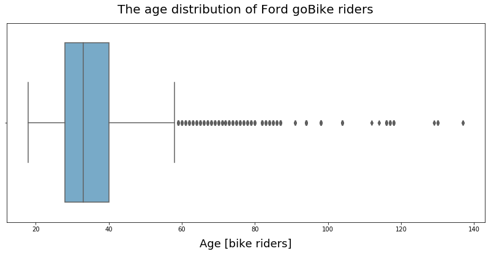

```python
plt.figure(figsize=(14,6))
sns.boxplot(x='member_age', data=df, palette='Blues', orient='h')
plt.title("The age distribution of Ford goBike riders", fontsize=20, y=1.03)
plt.xlabel("Age [bike riders]", fontsize=18, labelpad=10)
```

There are outliers. Age from 18 to 56 takes 95% of the users. So, it's logical to remove users more than 60 years old. There were users more than 100 years old.

```python
df=df.query('member_age<60')
```

```python
df['member_age'].describe()
```

```
count    1.549293e+06
mean     3.414470e+01
std      9.115845e+00
min      1.800000e+01
25%      2.700000e+01
50%      3.200000e+01
75%      3.900000e+01
max      5.900000e+01
Name: member_age, dtype: float64
```

```python
df.drop(['member_birth_year'], axis=1, inplace=True)
```

Mean Age of members using Gobikes is 34~35

```
Text(0.5,0,'Age [bike riders]')
```

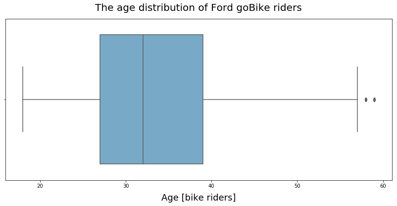

```python
plt.figure(figsize=(14,6))
sns.boxplot(x='member_age', data=df, palette='Blues', orient='h')
plt.title("The age distribution of Ford goBike riders", fontsize=20, y=1.03)
plt.xlabel("Age [bike riders]", fontsize=18, labelpad=10)
```

```python
df['start_time']
```

```
94800     2018-01-01 00:07:52.943
94799     2018-01-01 00:09:31.745
94793     2018-01-01 00:14:37.187
94770     2018-01-01 00:15:33.369
94766     2018-01-01 00:17:54.588
94764     2018-01-01 00:19:49.117
94792     2018-01-01 00:20:47.360
94784     2018-01-01 00:28:16.128
94771     2018-01-01 00:38:57.383
94769     2018-01-01 00:39:18.607
94767     2018-01-01 00:39:45.670
94772     2018-01-01 00:40:34.541
94785     2018-01-01 00:41:11.231
94786     2018-01-01 00:41:11.435
94765     2018-01-01 00:41:38.444
```

[output cut: 47 more lines]

```python
df.isna().sum()
```

```
duration_sec               0
start_time                 0
end_time                   0
start_station_id           0
start_station_name         0
start_station_latitude     0
start_station_longitude    0
end_station_id             0
end_station_name           0
end_station_latitude       0
end_station_longitude      0
bike_id                    0
user_type                  0
member_gender              0
bike_share_for_all_trip    0
member_age                 0
dtype: int64
```

# Generate new fields for date from start_time and end_time

```python
df['start_time_date']=df['start_time'].dt.date
df['end_time_date']=df['end_time'].dt.date
df['start_time_year_month_renamed'] = df['start_time'].dt.strftime('%y' + '-' + '%m')
```